# Análise dos Gastos com Cartão Corporativo

Alan Gularte

## Leitura e Limpeza

```r
library(dplyr)
library(magrittr)
library(lubridate)
library(ggplot2)
library(skimr)
library(tidyr)
library(highcharter)
library(devtools)
library(DT)
require(scales)

gastos <- readRDS('data/gastos_cartao.rds')

# Converter data da transacao para o tipo date e para o formato YYYY-MM-DD para facilitar as operacoes
gastos <- gastos %>%
  mutate(
    data_transacao = as.Date(data_transacao, format = '%d/%m/%Y'),
    dia_transacao = as.numeric(format(data_transacao, format = "%d")),
    mes_transacao = as.numeric(format(data_transacao, format = "%m")),
    ano_transacao = as.numeric(format(data_transacao, format = "%Y")),
    periodo_transacao = as.Date(paste(ano_transacao,mes_transacao,"1",sep="-"), format = '%Y-%m-%d')
  )

gastos %>%
  skim()
```

```
## Skim summary statistics
##  n obs: 765539
##  n variables: 19
##
## -- Variable type:character ---------------------------------------------------------------------------------------------------------------------------------
##                variable missing complete      n min max  empty n_unique
##  cnpj_ou_cpf_favorecido       0   765539 765539   3  21      0    90051
##            cpf_portador       0   765539 765539   0  14 121107    13462
##         nome_favorecido       0   765539 765539   5 139      0    80690
##              nome_orgao       0   765539 765539  16  89      0      196
##     nome_orgao_superior       0   765539 765539  19  45      0       22
##           nome_portador       0   765539 765539   8  52      0    13525
##    nome_unidade_gestora       0   765539 765539   9  46      0     1433
##               transacao       0   765539 765539  17  36      0        8
##
## -- Variable type:Date --------------------------------------------------------------------------------------------------------------------------------------
##           variable missing complete      n        min        max
##     data_transacao  121107   644432 765539 2013-11-04 2019-02-25
##  periodo_transacao  121107   644432 765539 2013-11-01 2019-02-01
##      median n_unique
##  2016-05-25     1900
##  2016-05-01       64
##
## -- Variable type:integer -----------------------------------------------------------------------------------------------------------------------------------
##                variable missing complete      n      mean       sd     p0
##             ano_extrato       0   765539 765539   2015.97     1.5    2014
##            codigo_orgao       0   765539 765539  29810.75  9893.26  20101
##   codigo_orgao_superior       0   765539 765539  29782.33 10158.06  20000
##  codigo_unidade_gestora       0   765539 765539 185390.41 91489.07 110001
##             mes_extrato       0   765539 765539      6.99     3.42      1
##     p25    p50   p75   p100     hist
##    2015   2016  2017   2019 ▇▇▁▆▆▁▆▁
##   25000  26236 30108  91214 ▇▂▁▁▁▁▁▁
##   25000  26000 30000  81000 ▇▂▁▁▂▁▁▁
##  114624 158126 2e+05 913001 ▇▁▁▁▁▁▁▁
##       4      7    10     12 ▅▂▇▃▃▇▃▇
##
## -- Variable type:numeric -----------------------------------------------------------------------------------------------------------------------------------
##         variable missing complete      n    mean      sd      p0  p25
##    ano_transacao  121107   644432 765539 2015.89    1.51 2013    2015
##    dia_transacao  121107   644432 765539   15.93    8.58    1       9
##    mes_transacao  121107   644432 765539    6.97    3.22    1       4
##  valor_transacao       0   765539 765539  370.27 1190.87    0.03   70
##      p50  p75      p100     hist
##  2016    2017   2019    ▁▇▇▆▁▇▆▁
##    16      23     31    ▆▇▇▇▆▇▇▆
##     7      10     12    ▅▃▇▃▃▇▅▇
##   158.88  411 129742.94 ▇▁▁▁▁▁▁▁
```

# Hipótese 1: Uma visão geral dos gastos

Como será que foi o uso do cartão corporativo de 2014 a 2019?

```r
gastos %>%
  filter(!is.na(periodo_transacao)) %>%
  group_by(periodo_transacao) %>%
  summarise(total = round(sum(valor_transacao, na.rm = TRUE),3)) %>%
  hchart("line",
         name = "Total de Despesas",
         hcaes(x = periodo_transacao, y = total),
         color = "#cc8800"
  )
```

[interactive chart not shown]

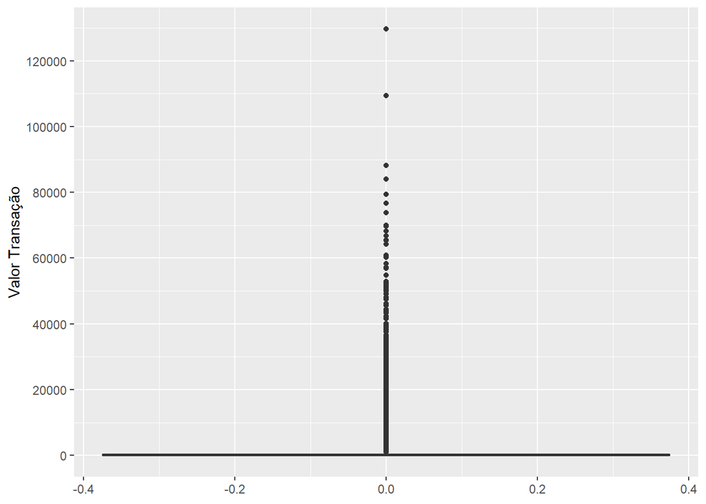

```r
options(scipen=10000)

dates = seq(as.Date("01-01-2007",  format = "%d-%m-%Y"), length.out = 120, by = "month")
df <- data.frame(dates)

gastos %>%
  select(ano_extrato,valor_transacao) %>%
  ggplot(aes(y = valor_transacao)) +
  geom_boxplot() +
  scale_y_continuous(breaks = round(seq(min(gastos$valor_transacao), max(gastos$valor_transacao), by = 20000),1)) +
  ylab("Valor Transação")
```

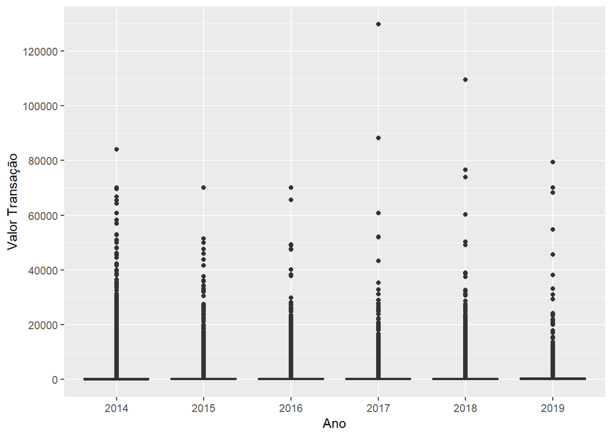

```r
gastos %>%
  select(ano_extrato,valor_transacao) %>%
  ggplot(aes(y = valor_transacao, x = factor(ano_extrato))) +
  geom_boxplot() +
  scale_y_continuous(breaks = round(seq(min(gastos$valor_transacao), max(gastos$valor_transacao), by = 20000),1)) +
  xlab("Ano") +
  ylab("Valor Transação")
```

# Hipótese 2: Órgãos com mais despesas

Quais são os órgãos que mais apresentaram gastos (em valores acumulados) no período pesquisado?

```r
gastos %>%
  group_by(nome_orgao_superior) %>%
  summarise(total = round(sum(valor_transacao, na.rm = TRUE),3)) %>%
  arrange(desc(total)) %>%
  hchart(type = "treemap",
         hcaes(x = nome_orgao_superior, value = total, color = total))
```

[interactive chart not shown]

# Hipótese 3: Unidades Gestoras da Presidência com mais despesas

Quais são as Unidades Gestoras da Presidência que foram responsáveis pelos maiores gastos?

```r
gastos %>%
  filter(codigo_orgao_superior == "20000") %>% #código da presidência
  group_by(nome_unidade_gestora) %>%
  summarise(total = round(sum(valor_transacao, na.rm = TRUE),3)) %>%
  arrange(desc(total)) %>%
  #slice(1:10) %>%
  hchart(type = "treemap",
         hcaes(x = nome_unidade_gestora, value = total, color = total))
```

[interactive chart not shown]

# Hipótese 4: Distribuição dos gastos entre os órgãos

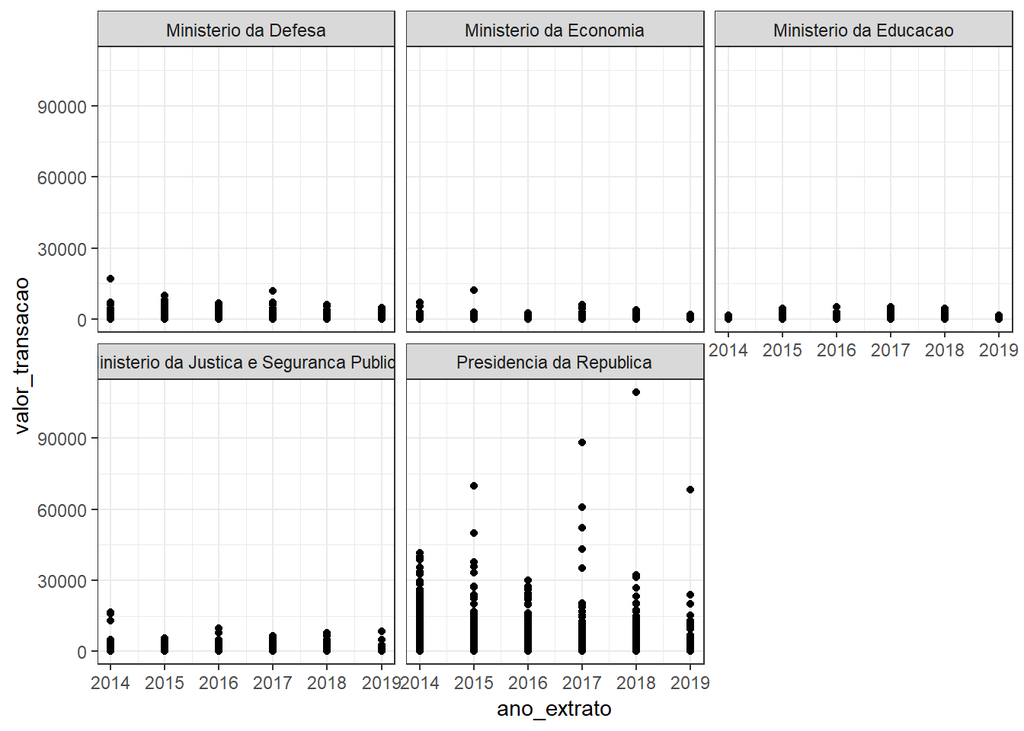

```r
gastos_top5 <- gastos %>%
  group_by(nome_orgao_superior) %>%
  summarise(total = round(sum(valor_transacao, na.rm = TRUE),3)) %>%
  arrange(desc(total)) %>%
  slice(1:5)

gastos %>%
  filter(nome_orgao_superior == c(gastos_top5$nome_orgao_superior)) %>%
  droplevels() %>%
  ggplot(aes(x = ano_extrato, y = valor_transacao)) +
  geom_point() +
  geom_smooth(aes(colour = nome_orgao_superior, fill = nome_orgao_superior)) +
  facet_wrap(~nome_orgao_superior) +
  theme_bw()
```

# Hipótese 5: Tipos de Transações

Quais são os tipos de transações presentes e seus respectivos gastos?

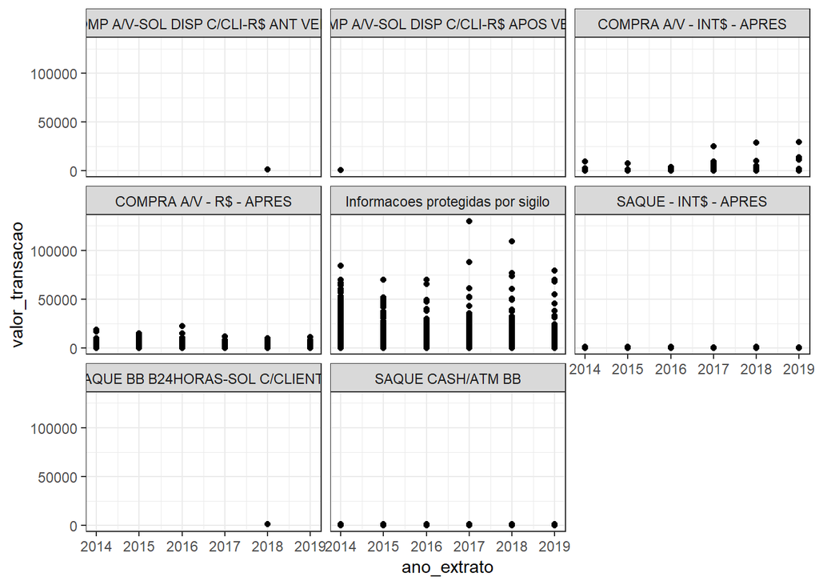

```r
gastos %>%
  droplevels() %>%
  ggplot(aes(x = ano_extrato, y = valor_transacao)) +
  geom_point() +
  geom_smooth(aes(colour = transacao, fill = transacao)) +
  facet_wrap(~transacao) +
  theme_bw()
```

# Hipótese 6: Transações Sigilosas

Quais são os órgãos que apresentam mais transações sigilosas?

```r
gastos_table <- gastos %>%
  filter(transacao == "Informacoes protegidas por sigilo") %>%
  group_by(nome_orgao_superior) %>%
  summarise(n=n(), total=sum(valor_transacao,na.rm = T),media=median(valor_transacao,na.rm = T)) %>%
  arrange(desc(n))

gastos_table %>%
  datatable(colnames = c('Órgão','Total de Transações', 'Valor Acumulado (R$)', 'Média das Despesas (R$)'))
```

|  | Órgão | Total de Transações | Valor Acumulado (R$) | Média das Despesas (R$) |
| --- | --- | --- | --- | --- |
| 1 | Ministerio da Justica e Seguranca Publica | 79442 | 62755903.42 | 1000 |
| 2 | Presidencia da Republica | 40251 | 72012565.42 | 704.97 |
| 3 | Ministerio da Economia | 1185 | 900799.52 | 800 |
| 4 | Ministerio da Defesa | 229 | 48659.1 | 130 |

# Considerações Finais

- O uso do cartão corporativo é realizado de forma sazonal, onde Novembro é o mês de maior utiização e Janeiro de menor utilização, talvez este último por ser o mês de recesso.
- Existem gastos com valores muito acima da média. Considerando todo o período, a média dos gastos foi de R$ 370.27, porém encontrou-se despesas com valores acima de R$ 100.000,00.
- A Presidência apresenta as maiores despesas, sendo que a sua maioria é de transações sigilosas (nenhuma identificação de origem, destino ou data disponíveis).
- A Agência Brasileira de Inteligência é responsável pelas maiores despesas da Presidência (acumulado de R$ 38M), seguida pela Secretaria de Administração/PR (acumulado de R$ 30M).
- As transações sigilosas são as responponsáveis pelas despesas mais caras, e estão presentes, em sua maioria (em quantidade), no Ministério da Justiça e Segurança Pública, Presidência da República, Ministério da Economia e Ministério da Defesa.

Nota: dentro do período pesquisado, o ano de 2014 foi o de maior gasto. Este foi um ano eleitoral e também o ano em que o Brasil hospedou a Copa do Mundo de Futebol. Será que usou-se muito o cartão corporativo com gastos com a Copa? O cartão corporativo também foi utilizado para fins de campanha? Infelizmente o dataset carece de outras variáveis importantes, como o tipo de item (produto/serviço) envolvido nas despesas, para poder ter uma análise mais profunda.